# ANALYZING THE EFFECT OF VIOLENT VIDEO GAME PLAY ON MATE VALUE AND OTHER MATING RELATED VARIABLES

## General housekeeping

First load the libraries that we are using

```r
library(ggplot2)
library(knitr)
library(QuantPsyc)
library(PerformanceAnalytics)
library(heplots)
library(plyr)
require(gridExtra)
```

```r
data = read.csv(file.choose(),  na.strings =".", header=T, sep=",")
```

Attach and check the headers of each column

```r
names(data)
```

```
##   [1] "date"
##   [2] "time"
##   [3] "group"
##   [4] "subject"
##   [5] "build"
##   [6] "consentq_response"
##   [7] "X"
##   [8] "last30days_response"
##   [9] "recentgame1_response"
##  [10] "recentgame2_response"
##  [11] "recentgame3_response"
##  [12] "recentgame4_response"
##  [13] "recentgame5_response"
##  [14] "playfrequency1_response"
##  [15] "playfrequency2_response"
```

[output cut: 133 more lines]

Recode gender into numerical values

```r
data$Gender2 <- revalue(data$Gender, c("Male"="1", "Female"="2"))
data$Gender2 <- as.numeric(as.character(data$Gender2))
```

Recode violent/non-violent treatment into numerical values

```r
data$VorNV2 <- revalue(data$VorNV, c("V"="1", "NV"="2"))
data$VorNV2 <- as.numeric(as.character(data$VorNV2))
```

Ensuring that certain columns are treated as categorical

```r
data$Sexuality <- factor(data$Sexuality)
```

Delete Rows where participants were unable to load or play game, had issues with the survey loading, or failed an attention check (49 people).

```r
data<-data[-which(data$Removedata == "Yes"), ]
```

```r
#data$mc_MV1Total <- scale(data$MV1Total, center = TRUE, scale = TRUE)
#data$mc_SOIRTOTAL <- scale(data$SOIRTOTAL, center = TRUE, scale = TRUE)
#data$mc_MV2Average <- scale(data$MV2Average, center = TRUE, scale = TRUE)
#data$mc_SGAAverage <- scale(data$SGAAverage, center = TRUE, scale = TRUE)
#data$mc_HostilityTotal <- scale(data$HostilityTotal, center = TRUE, scale = TRUE)
#data$mc_MMTotal <- scale(data$MMTotal, center = TRUE, scale = TRUE)
```

First, check the distributions of all the variables of interest

`r hist(data$MV1Total)`

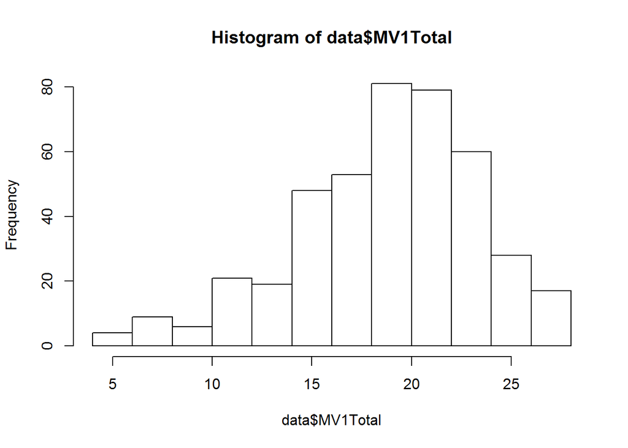

`r hist(data$MV2Average)`

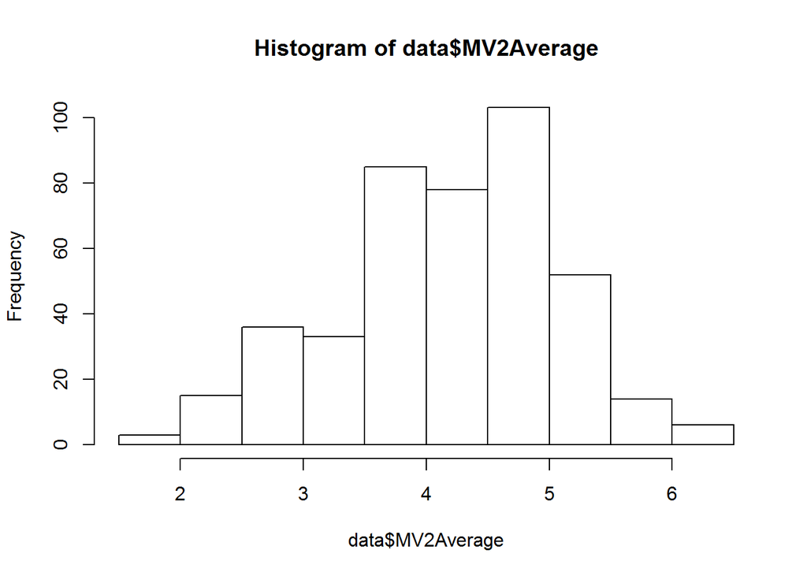

`r hist(data$SGAAverage)`

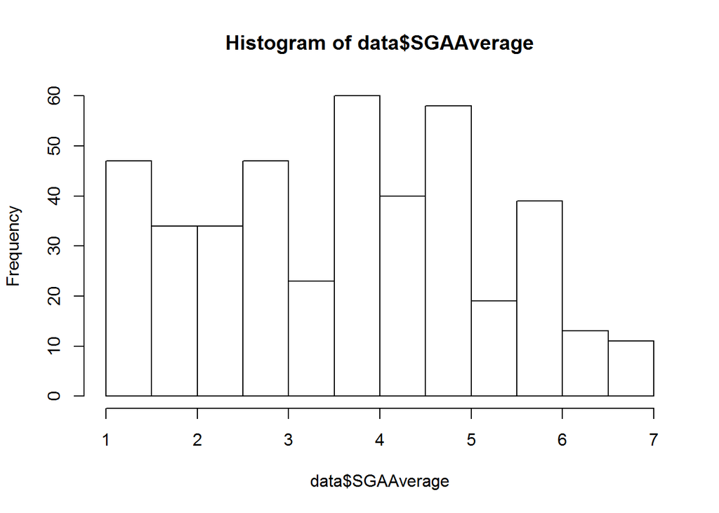

`r hist(data$HostilityTotal)`

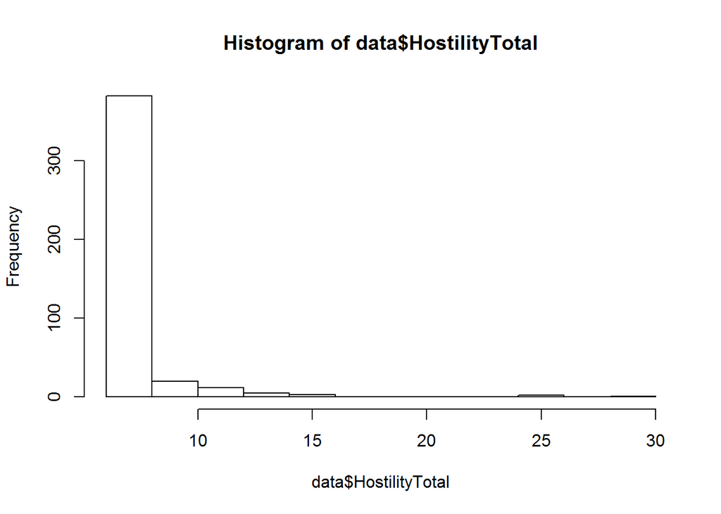

`r hist(data$SOIRTotal)`

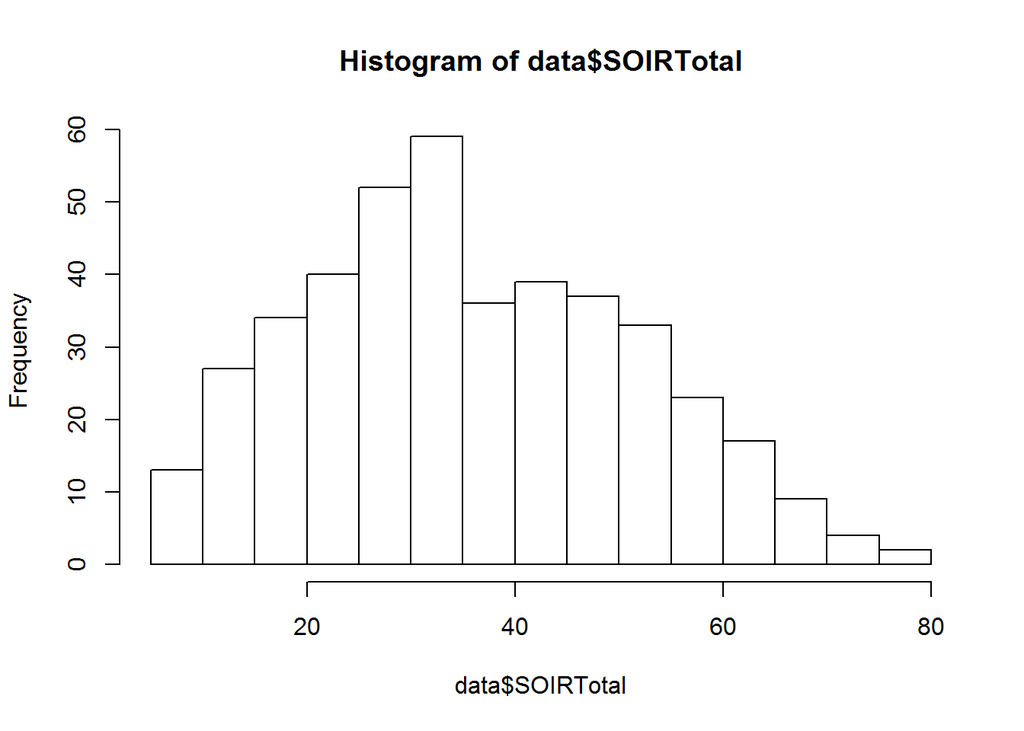

`r hist(data$MMTotal)`

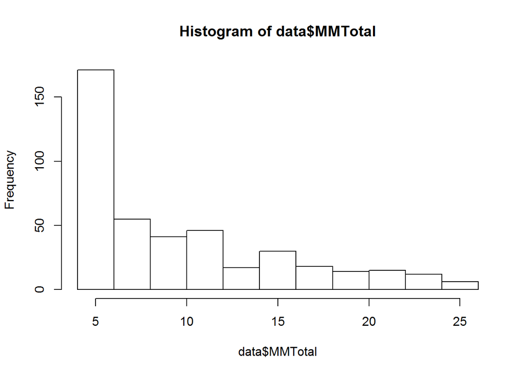

The ditributions for all of them are fine, except for Hostility Total and Mating Motivation. HT specifically has very little variation in it, so I don’t think it will be very useful and am happy to remove it from the models. MM has a terrible skew and no transformations will really help. As a result, I think it would be alright to remove that from the model as well.

What is the mean, SD and range of the age of respondents in the first sample?

`r mean(data$Age)`

`## [1] 33.78353`

`r sd(data$Age)`

`## [1] 9.416976`

`r range(data$Age)`

`## [1] 18 71`

Do men and women differ in the amount of violent video games they play (self-rated)

`r VVGSex1 <- lm(Averagefrequencyviolence ~ Age + Gender + Age*Gender, data = data) anova(VVGSex1, test="Chisq")`

`## Analysis of Variance Table ## ## Response: Averagefrequencyviolence ## Df Sum Sq Mean Sq F value Pr(>F) ## Age 1 1386 1386.23 18.2581 2.388e-05 *** ## Gender 1 1955 1955.48 25.7557 5.826e-07 *** ## Age:Gender 1 148 148.37 1.9542 0.1629 ## Residuals 421 31964 75.92 ## --- ## Signif. codes: 0 '***' 0.001 '**' 0.01 '*' 0.05 '.' 0.1 ' ' 1`